# Day-04: Integration and Modularity

## **Content Description**

Characterizing patterns of integration and modularity are hugely important in morphometrics. At their core, these methods seek to summarize patterns of trait covariation, as found in the trait covariance matrix: $\hat{\mathbf\Sigma} = \mathbf{Z^T}\mathbf{Z}/ (n-1)$. There are three general classes of methods:

- 1: Methods for evaluating and comparing overall integration
- 2: Methods for evaluating and comparing integration among subsets of traits
- 3: Methods for evaluating and comparing modularity

`Geomorph implements approaches addressing all three of these (See lecture for detailed description of methods).

```r
library(geomorph)
```

## **1: Overall Integration**

Here we use an effect size based on $V_{rel}$ to quantify and compare overall levels of integration in a set of traits.

```r
data("plethodon")
Y.gpa <- gpagen(plethodon$land, print.progress = FALSE)
#Separate data by species
coords.gp <- coords.subset(Y.gpa$coords, plethodon$species)

#Z_Vrel by species
Vrel.gp <- Map(function(x) integration.Vrel(x), coords.gp)
compare.ZVrel(Vrel.gp$Jord, Vrel.gp$Teyah)
```

```
##
## Effect sizes
##
##  Vrel.gp$Jord Vrel.gp$Teyah
##    -0.2978931    -0.2642648
##
## Effect sizes for pairwise differences in rel.eig effect size
##
##               Vrel.gp$Jord Vrel.gp$Teyah
## Vrel.gp$Jord    0.00000000    0.09804249
## Vrel.gp$Teyah   0.09804249    0.00000000
##
## P-values
##
##               Vrel.gp$Jord Vrel.gp$Teyah
## Vrel.gp$Jord     1.0000000     0.9218986
## Vrel.gp$Teyah    0.9218986     1.0000000
```

## **1B: Overall Integration Across Spatial Scales**

A method for evaluating integration across spatial scales is also implemented

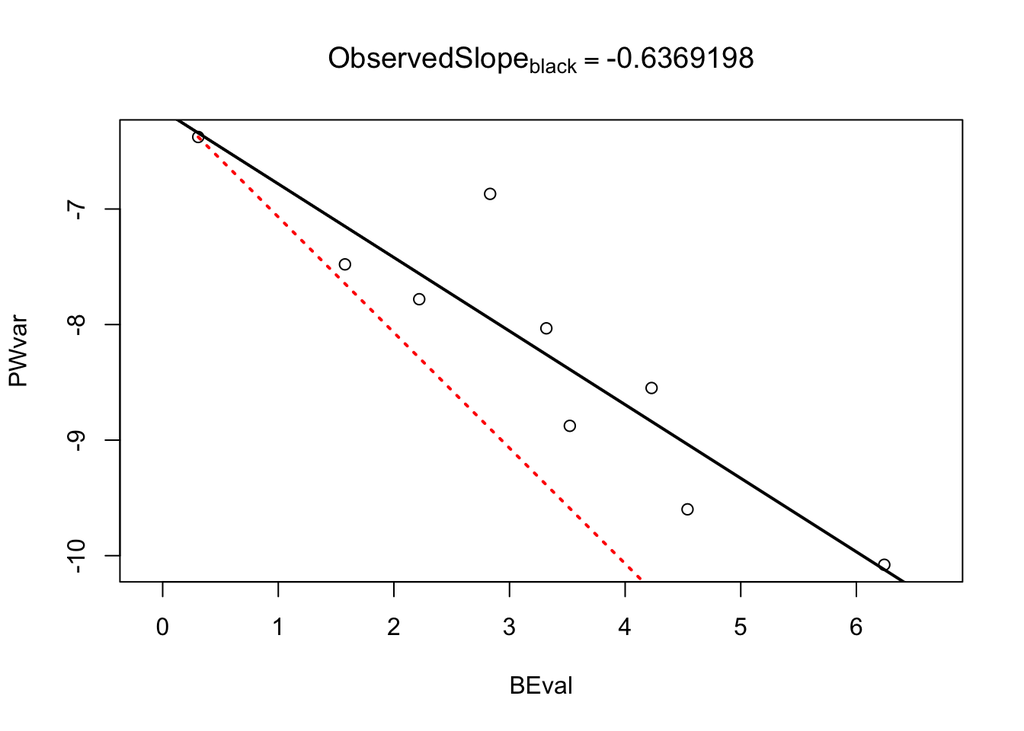

```
##      BEval
## -0.6369198
```

```r
globalIntegration(Y.gpa$coords) #data are not spatially integrated
```

## **2: Integration between Subsets of Traits**

Here, one may use PLS to evaluate the covariation between subsets of traits:

```r
data(pupfish) # GPA previously performed
group <- factor(paste(pupfish$Pop, pupfish$Sex, sep = "."))

# Subset 3D array by group, returning a list of 3D arrays
tail.LM <- c(1:3, 5:9, 18:38)
head.LM <- (1:56)[-tail.LM]
tail.coords <- pupfish$coords[tail.LM,,]
head.coords <- pupfish$coords[head.LM,,]

IT <- integration.test(tail.coords, head.coords, print.progress = F)
```

```
##
## No names for A2.  Data are assumed to be ordered as in A.
```

```r
summary(IT)
```

```
##
## Call:
## integration.test(A = tail.coords, A2 = head.coords, print.progress = F)
##
##
##
## r-PLS: 0.917
##
## Effect Size (Z): 5.4983
##
## P-value: 0.001
##
## Based on 1000 random permutations
```

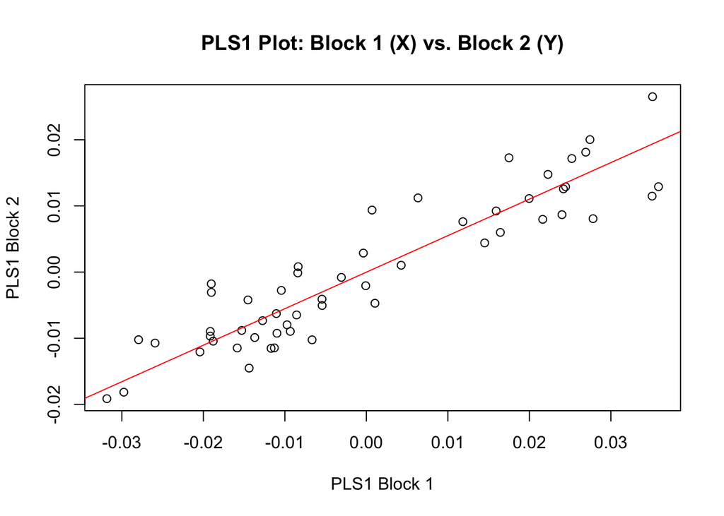

```r
plot(IT)
```

One could also use a partition of landmarks (NOTE identical $r_{PLS}$:

```r
land.gp <- rep(1,56); land.gp[tail.LM] <- 2
integration.test(pupfish$coords, partition.gp=land.gp, print.progress = FALSE)
```

```
##
## Call:
## integration.test(A = pupfish$coords, partition.gp = land.gp,
##     print.progress = FALSE)
##
##
##
## r-PLS: 0.917
##
## Effect Size (Z): 5.4019
##
## P-value: 0.001
##
## Based on 1000 random permutations
```

And the statistical results are the same as when using two.b.pls

```r
two.b.pls(tail.coords, head.coords, print.progress = FALSE)
```

```
## Data in either A1 or A2 do not have names.  It is assumed data in both A1 and A2 are ordered the same.
```

```
##
## Call:
## two.b.pls(A1 = tail.coords, A2 = head.coords, print.progress = FALSE)
##
##
##
## r-PLS: 0.917
##
## Effect Size (Z): 5.4983
##
## P-value: 0.001
##
## Based on 1000 random permutations
```

`picknplot.shape` example is provided in lab script.

## **2B: Comparing the Strength of Integration**

One may also evaluate whether the strength of integration similar in two or more groups. As above this is accomplished using effect sizes, this time based on $r_{PLS}$.

```r
tail.coords.gp <- coords.subset(tail.coords, group)
head.coords.gp <- coords.subset(head.coords, group)

# Obtain Integration for groups
integ.tests <- Map(function(x,y) integration.test(x, y, iter=499,
                print.progress = FALSE), head.coords.gp, tail.coords.gp)
compare.pls(integ.tests)
```

```
##
## Effect sizes
##
##    Marsh.F    Marsh.M Sinkhole.F Sinkhole.M
##  3.1410345  1.5130737  0.7429882  2.7156556
##
## Effect sizes for pairwise differences in PLS effect size
##
##              Marsh.F   Marsh.M Sinkhole.F Sinkhole.M
## Marsh.F    0.0000000 0.6586628  1.9027247  0.7518767
## Marsh.M    0.6586628 0.0000000  0.8778808  1.1927859
## Sinkhole.F 1.9027247 0.8778808  0.0000000  2.0927712
## Sinkhole.M 0.7518767 1.1927859  2.0927712  0.0000000
##
## P-values
##
##               Marsh.F   Marsh.M Sinkhole.F Sinkhole.M
## Marsh.F    1.00000000 0.5101123 0.05707647 0.45212519
## Marsh.M    0.51011230 1.0000000 0.38000838 0.23295324
## Sinkhole.F 0.05707647 0.3800084 1.00000000 0.03636958
## Sinkhole.M 0.45212519 0.2329532 0.03636958 1.00000000
```

## **3: Modularity among Subsets of Traits**

Tests of modularity can also be performed in `geomorph`:

```r
MT <- modularity.test(pupfish$coords,land.gp,CI=FALSE,print.progress = FALSE)
summary(MT)
```

```
##
## Call:
## modularity.test(A = pupfish$coords, partition.gp = land.gp, CI = FALSE,
##     print.progress = FALSE)
##
##
##
## CR: 0.8771
##
## P-value: 0.003
##
## Effect Size: -4.5427
##
## Based on 1000 random permutations
```

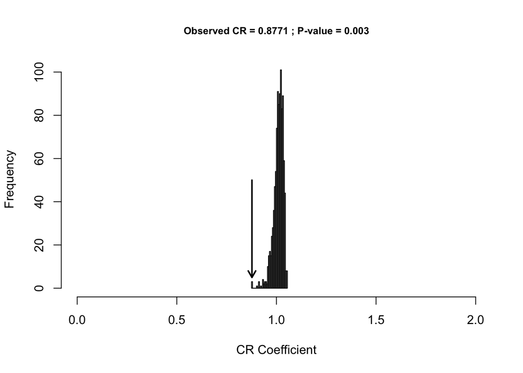

```r
plot(MT)
```

## **3B: Comparing the Strength of Modularity**

One may also evaluate whether the strength of modularity similar in two or more groups. As above this is accomplished using effect sizes based on $CR$.

```r
coords.gp <- coords.subset(pupfish$coords, group)
modul.tests <- Map(function(x) modularity.test(x, land.gp,print.progress = FALSE), coords.gp)
compare.CR(modul.tests, CR.null = FALSE)
```

```
##
##  NOTE: more negative effects represent stronger modular signal!
##
##
## Effect sizes
##
##    Marsh.F    Marsh.M Sinkhole.F Sinkhole.M
##  -2.816188  -5.778451  -3.363544  -4.534488
##
## Effect sizes for pairwise differences in CR effect size
##
##             Marsh.F   Marsh.M Sinkhole.F Sinkhole.M
## Marsh.F    0.000000 2.5466647  1.8303913   1.017783
## Marsh.M    2.546665 0.0000000  0.1496676   1.693290
## Sinkhole.F 1.830391 0.1496676  0.0000000   1.251317
## Sinkhole.M 1.017783 1.6932905  1.2513171   0.000000
##
## P-values
##
##               Marsh.F    Marsh.M Sinkhole.F Sinkhole.M
## Marsh.F    1.00000000 0.01087579 0.06719144 0.30878104
## Marsh.M    0.01087579 1.00000000 0.88102690 0.09040019
## Sinkhole.F 0.06719144 0.88102690 1.00000000 0.21081881
## Sinkhole.M 0.30878104 0.09040019 0.21081881 1.00000000
```

## **3B-2: Comparing Alternative Modular Hypotheses**

One may also wish to determine whether there is support in a given dataset for a 2-module, 3-module, 4-module, or other hypothesis. This is also accomplished via effect sizes of $CR$.

```r
land.gps3 <- rep('a',56); land.gps3[39:48]<-'b'; land.gps3[c(6:9,28:38)] <- 'c'
#3 module hypothesis (tail now a module)
land.gps4 <- rep('a',56); land.gps4[39:48]<-'b'; land.gps4[c(6:9,28:38)] <- 'c';
land.gps4[c(10,49:56)] <- 'd'  #4 module hypothesis (eye now a module)

m3.test <- modularity.test(coords.gp$Marsh.F,land.gps3, iter = 499, print.progress = FALSE)
m4.test <- modularity.test(coords.gp$Marsh.F,land.gps4, iter = 499, print.progress = FALSE)

model.Z <- compare.CR(m3.test,m4.test, CR.null = TRUE)
model.Z
```

```
##
##  NOTE: more negative effects represent stronger modular signal!
##
##
## Effect sizes
##
## No_Modules    m3.test    m4.test
##   0.000000  -3.055068  -3.873177
##
## Effect sizes for pairwise differences in CR effect size
##
##            No_Modules  m3.test  m4.test
## No_Modules   0.000000 3.055068 3.873177
## m3.test      3.055068 0.000000 1.030587
## m4.test      3.873177 1.030587 0.000000
##
## P-values
##
##              No_Modules     m3.test      m4.test
## No_Modules 1.0000000000 0.002250096 0.0001074256
## m3.test    0.0022500958 1.000000000 0.3027346572
## m4.test    0.0001074256 0.302734657 1.0000000000
```